# Preparation

To assess the hierarchical structure of all indices, we performed hierarchical cluster analysis as well.

**Hierarchical cluster analysis**:

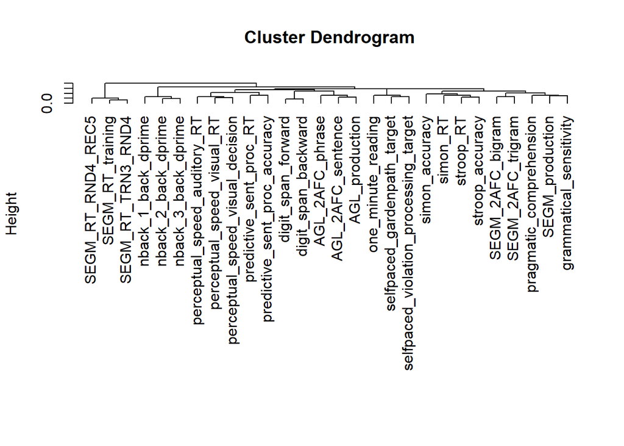

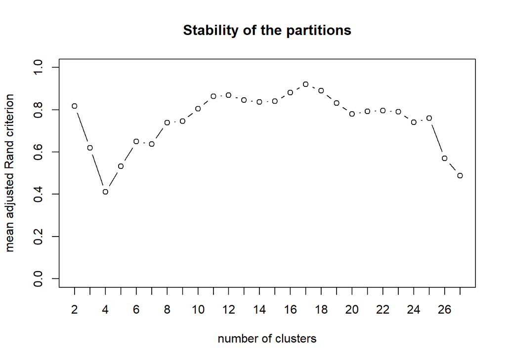

Since the Rand criterion shows that there is two local maxima (at 11-12 and 17) regarding the number of clusters, we selected the smaller number to get more information about the relationship of the indices.

**K-means cluster analysis**:

```
##
## Call:
## kmeansvar(X.quanti = ., init = 12, nstart = 1000)
##
## number of iterations:  1
##
## Data:
##    number of observations:  608
##    number of variables:  28
##    number of clusters:  12
##
## Cluster  1 :
##                   squared loading correlation
## SEGM_RT_TRN3_RND4            0.89       -0.94
## SEGM_RT_training             0.64       -0.80
## SEGM_RT_RND4_REC5            0.64       -0.80
##
##
## Cluster  2 :
##                   squared loading correlation
## SEGM_2AFC_trigram            0.67       -0.82
## SEGM_2AFC_bigram             0.67       -0.82
##
##
## Cluster  3 :
##                   squared loading correlation
## AGL_production               0.59       -0.77
## AGL_2AFC_sentence            0.59       -0.77
## AGL_2AFC_phrase              0.42       -0.65
##
##
## Cluster  4 :
##                                  squared loading correlation
## perceptual_speed_visual_RT                  0.71       -0.85
## perceptual_speed_visual_decision            0.56       -0.78
## perceptual_speed_auditory_RT                0.56       -0.75
##
##
## Cluster  5 :
##                     squared loading correlation
```

[output cut: 33 more lines]

```
## Cluster  11 :
##                                       squared loading correlation
## selfpaced_violation_processing_target            0.57        0.76
## selfpaced_gardenpath_target                      0.57        0.76
## one_minute_reading                               0.43        0.67
##
##
## Cluster  12 :
##                         squared loading correlation
## SEGM_production                    0.52        0.82
## grammatical_sensitivity            0.48        0.72
## pragmatic_comprehension            0.47        0.71
##
##
## Gain in cohesion (in %):  58.71
```

In conclusion, the hierarchical cluster shows similar clusters to both the novel EFA results and to the main model on a fine-grained level. However, the higher we go in the tree, the more mixed up the structure is. Notable, the indices of the three domains get scrambled, for instance SEGM production is closest to grammatical sensitivity, the AGL indices are closest to digit span indices. The results suggest an inconclusive higher level structure, which would prevent us from conducting either an ordinary latent variable regression or a more complex mediation analysis.